# How community richness changes along the estuary-sea continuum

We want to model how species richness changes from the estuary to the sea. To do so, we will quantify how the species richness changes along the salinity gradient.

## Preparing the data

We begin by loading our dataset.

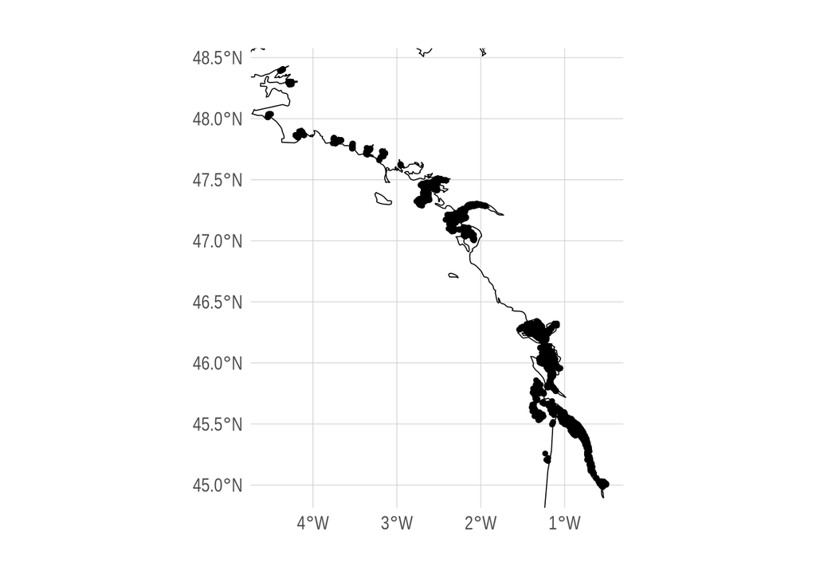

```r
data <- tar_read(fw_with_env) |>
  filter(dist_to_env < 5) |>
  mutate(
    salinity = sali_mean |> as.numeric()
  ) |>
  select(
    year,
    survey,
    log_species_richness,
    log_trophic_richness,
    longitude,
    latitude,
    salinity
  ) |>
  mutate(is_nurse = if_else(survey == "nurse", 1, 0))

plot_data_on_map(data)
```

Here is the map of our sampling points.

## Modeling alpha-diversity with salinity

Next, we want to model how species richness changes with salinity. To do that properly with to account for spatial autocorrelation.

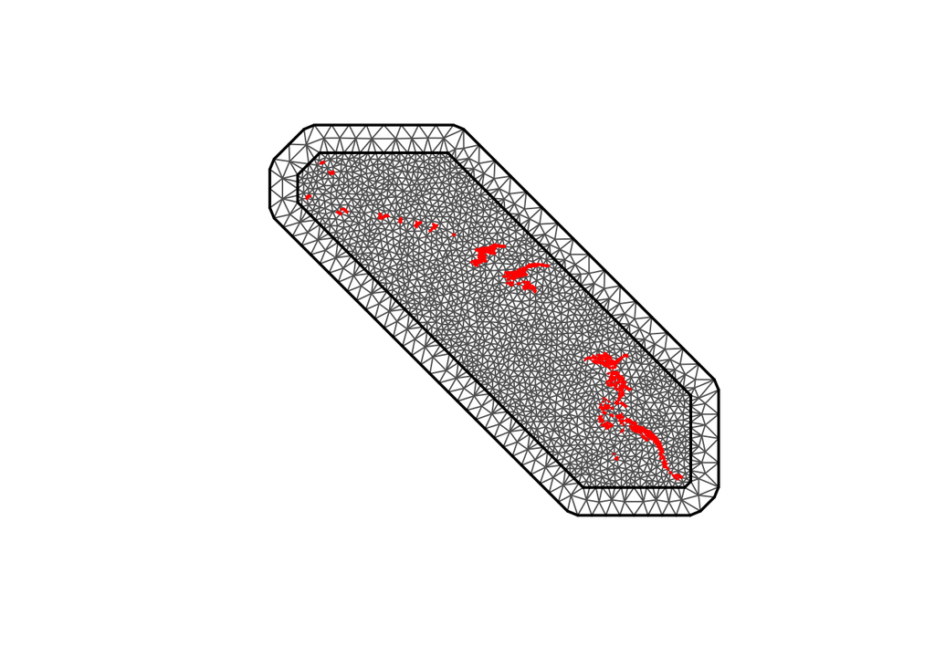

```r
library(INLA)
library(fmesher)

coords <- cbind(data$longitude, data$latitude)

mesh <- fmesher::fm_mesh_2d_inla(
  loc       = coords,
  max.edge  = c(0.1, 0.5),
  offset    = c(0.1, 0.3),
  cutoff    = 0.05
)
plot(mesh)
points(coords, col = "red", cex = 0.1, pch = 3)
```

Using a Spatial Gaussian Random Field on our mesh, we can fit a model that accounts for spatial autocorrelation.

```r
spde <- inla.spde2.pcmatern(
  mesh = mesh,
  prior.range = c(0.5, 0.5),
  prior.sigma = c(1, 0.01)
)

A <- inla.spde.make.A(mesh = mesh, loc = coords)

stk <- inla.stack(
  data = list(y = data$log_species_richness),
  A = list(A, 1),
  effects = list(
    list(spatial.field = 1:spde$n.spde),
    list(
      intercept = rep(1, nrow(data)),
      salinity = data$salinity,
      is_nurse = data$is_nurse,
      year = data$year
    )
  ),
  tag = "obs"
)

m1 <- inla(
  y ~ -1 +
    intercept +
    salinity +
    is_nurse +
    f(year, model = "iid") + f(spatial.field, model = spde),
  data = inla.stack.data(stk),
  control.predictor = list(
    A = inla.stack.A(stk),
    compute = TRUE
  ),
  control.compute = list(
    waic = TRUE,
    config = TRUE
  )
)

summary(m1)
```

```
Time used:
    Pre = 0.573, Running = 1.61, Post = 0.229, Total = 2.42
Fixed effects:
            mean    sd 0.025quant 0.5quant 0.975quant   mode kld
intercept  2.545 0.066      2.415    2.544      2.677  2.545   0
salinity   0.006 0.002      0.002    0.006      0.010  0.006   0
is_nurse  -0.061 0.014     -0.088   -0.061     -0.034 -0.061   0

Random effects:
  Name    Model
    year IID model
   spatial.field SPDE2 model

Model hyperparameters:
                                           mean      sd 0.025quant 0.5quant
Precision for the Gaussian observations  47.903   1.175     45.669   47.876
Precision for year                      543.268 188.850    248.812  517.720
Range for spatial.field                   0.217   0.052      0.139    0.210
Stdev for spatial.field                   0.116   0.012      0.094    0.115
                                        0.975quant    mode
Precision for the Gaussian observations     50.296  47.793
Precision for year                         982.064 470.694
Range for spatial.field                      0.342   0.192
Stdev for spatial.field                      0.143   0.113

Watanabe-Akaike information criterion (WAIC) ...: -3508.98
Effective number of parameters .................: 118.19

Marginal log-Likelihood:  1628.56
 is computed
Posterior summaries for the linear predictor and the fitted values are computed
(Posterior marginals needs also 'control.compute=list(return.marginals.predictor=TRUE)')
```

Next, we can investigate our model.

```r
spde.result <- inla.spde2.result(m1, "spatial.field", spde, do.transf = TRUE)

inla.emarginal(function(x) x, spde.result$marginals.range.nominal[[1]])
```

```
[1] 0.2173368
```

This captures the caracteristic range of the spatial autocorrelation. It is quite small, meaning that it acts at a small spatial scale, and our data is not too sensitive to this biais. This may be due to the act that our data is quite noisy due to fishing operations that may often miss many species. So even at the same place, two communities may not be too strongly correlated due to the sampling noise.

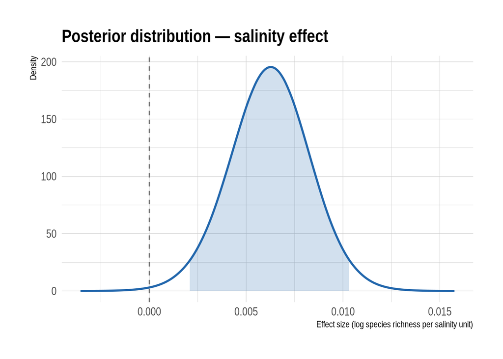

```r
sal_marginal <- m1$marginals.fixed$salinity

# Convert to a data frame for plotting the full posterior density
sal_df <- as.data.frame(inla.smarginal(sal_marginal))

ggplot(sal_df, aes(x = x, y = y)) +
  geom_line(linewidth = 1, colour = "#2166ac") +
  geom_vline(xintercept = 0, linetype = "dashed", colour = "grey40") +
  # 95% credible interval shading
  geom_ribbon(
    data = subset(sal_df, x >= inla.hpdmarginal(0.95, sal_marginal)[1] &
      x <= inla.hpdmarginal(0.95, sal_marginal)[2]),
    aes(ymin = 0, ymax = y), fill = "#2166ac", alpha = 0.2
  ) +
  labs(
    title = "Posterior distribution — salinity effect",
    x     = "Effect size (log species richness per salinity unit)",
    y     = "Density"
  )
```

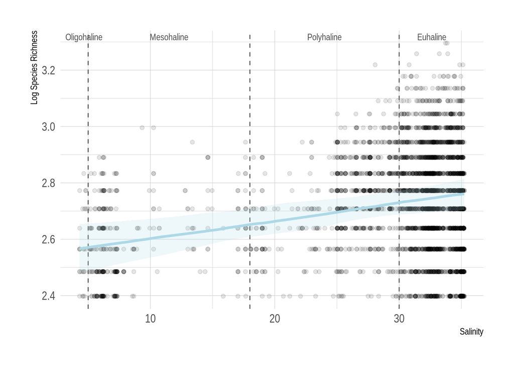

```r
n_samples <- 100
samples <- inla.posterior.sample(n_samples, m1)
beta_int_samples <- sapply(samples, function(s) s$latent["intercept:1", ])
beta_sal_samples <- sapply(samples, function(s) s$latent["salinity:1", ])
sal_seq <- seq(min(data$salinity), max(data$salinity), length.out = 200)

pred_matrix <- outer(rep(1, 200), beta_int_samples) +
  outer(sal_seq, beta_sal_samples)

pred_df <- data.frame(
  salinity = sal_seq,
  fit      = apply(pred_matrix, 1, median),
  lwr      = apply(pred_matrix, 1, quantile, probs = 0.045),
  upr      = apply(pred_matrix, 1, quantile, probs = 0.955)
)

zones <- data.frame(
  xmin  = c(-Inf, 0.5, 5, 18, 30),
  xmax  = c(0.5, 5, 18, 30, Inf),
  label = c("Freshwater", "Oligohaline", "Mesohaline", "Polyhaline", "Euhaline"),
  fill  = c("#a8d5f5", "#d4edda", "#fff3b0", "#f4a96a", "#e07b7b")
)

# Clip zones to your actual data range
x_min_data <- min(data$salinity)
x_max_data <- max(data$salinity)

zones$xmin <- pmax(zones$xmin, x_min_data)
zones$xmax <- pmin(zones$xmax, x_max_data)

# Drop zones outside your data range
zones <- zones[zones$xmin < zones$xmax, ]

ggplot(pred_df, aes(x = salinity)) +
  geom_point(
    data = data, aes(x = salinity, y = log_species_richness),
    alpha = 0.1
  ) +
  geom_vline(
    xintercept = c(5, 18, 30),
    linetype = "dashed", colour = "grey40", linewidth = 0.5
  ) +
  geom_text(
    data = zones,
    aes(x = (xmin + xmax) / 2, y = Inf, label = label),
    vjust = 1.5, size = 3.2, colour = "grey30",
    inherit.aes = FALSE
  ) +
  geom_ribbon(aes(ymin = lwr, ymax = upr), fill = "lightblue", alpha = 0.2) +
  geom_line(aes(y = fit), colour = "lightblue", linewidth = 1.2) +
  labs(
    x = "Salinity",
    y = "Log Species Richness"
  )
```

## Modeling alpha, beta and gamma diversity with salinity

Next, we focus on the different aspects of species diversity

- alpha-diversity, that is, the diversity of local communities
- beta-diversity, that is, how species composition changes
- gamma-diversity, that is, the aggregated diversity

Here, for simplicity we compute beta diversity as the ratio of gamma to alpha diversity.

First, we will focus only on the Garonne estuary, to compare sites that are comparable.

```r
data <- tar_read(fw_with_env) |>
  filter(dist_to_env < 5) |>
  rename(trait = operation_id)

district <- tar_read(fw_with_district) |>
  select(trait = operation_id, year, zone_id, district)

data <- data |>
  left_join(district, by = join_by(trait, year)) |>
  mutate(
    salinity = sali_mean |> as.numeric()
  ) |>
  select(
    trait,
    year,
    survey,
    log_species_richness,
    log_trophic_richness,
    longitude,
    latitude,
    salinity,
    foodweb, #  Now kept to extract species composition.
    district,
    zone_id,
    substrat,
    bathymetry,
    sali_perc_90,
    chl_mean,
    nppv_mean,
    substrat,
    temp_mean,
    temp_cv,
    o2_mean,
    o2_cv,
    wave_mean
  ) |>
  mutate(is_nurse = if_else(survey == "nurse", 1, 0))

data <- data |>
  filter(district == "Ardour-Garonne")
```

First let’s plot our sampling points and the salinity gradient on a map.

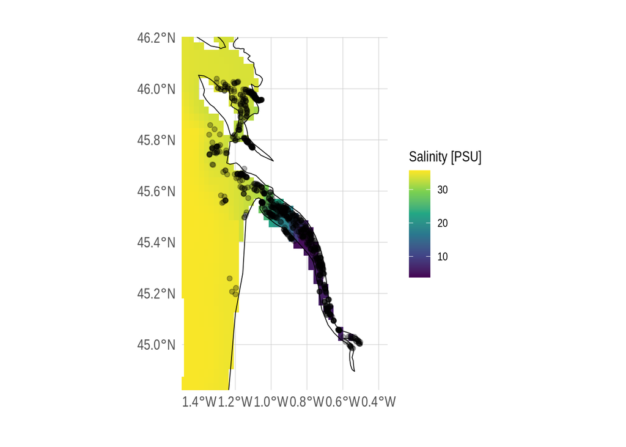

```r
environment_data <- tar_read(environment_data)

coastline <- rnaturalearth::ne_coastline(scale = "large", returnclass = "sf")

e <- c(-0.1, 0.1)
environment_data |>
  group_by(year, x, y) |>
  summarise(salinity = mean(sali_mean), .groups = "drop") |>
  ggplot(aes(x = x, y = y, fill = salinity)) +
  geom_tile() +
  geom_sf(data = coastline, inherit.aes = FALSE, linewidth = 0.3) +
  scale_fill_viridis_c() +
  geom_point(data, mapping = aes(longitude, latitude), alpha = 0.3) +
  coord_sf(xlim = range(data$longitude) + e, ylim = range(data$latitude) + e) +
  labs(x = NULL, y = NULL, fill = "Salinity [PSU]")
```

We then compute species composition for each local community to compute the three measure of diversity.

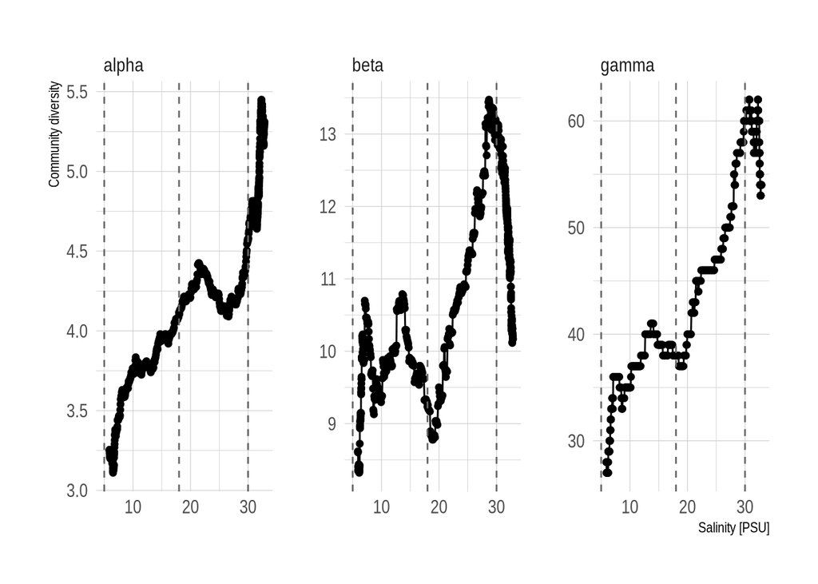

```r
resource_list <- tar_read(resource_list)

get_species <- function(web) {
  sub("_.*", "", colnames(web)) |>
    unique() |>
    setdiff(resource_list)
}

data <- data |>
  mutate(
    species = purrr::map(foodweb, get_species),
    species_richness = purrr::map_dbl(species, length)
  ) |>
  arrange(salinity)

plot_rolling_window <- function(data, window) {
  diversity_df <- purrr::map_dfr(
    seq_len(nrow(data) - window + 1),
    function(i) {
      w <- data[i:(i + window - 1), ]
      tibble(
        salinity = mean(w$salinity),
        gamma = n_distinct(unlist(w$species)),
        alpha = mean(w$species_richness)
      )
    }
  ) |>
    mutate(beta = gamma / alpha) |>
    tidyr::pivot_longer(cols = c(alpha, beta, gamma), names_to = "diversity")
  ggplot(diversity_df, aes(salinity, value)) +
    geom_point() +
    geom_line() +
    geom_vline(
      xintercept = c(5, 18, 30),
      linetype = "dashed", colour = "grey40", linewidth = 0.5
    ) +
    facet_wrap("diversity", scales = "free_y") +
    labs(x = "Salinity [PSU]", y = "Community diversity")
}

plot_rolling_window(data, 200)
```

First, we see that both alpha and gamma diversity increases with salinity, suggesting that communities become richer through the apparition of marine species, and that the brackish diversity is lower.

We observe two peaks in beta diversitt, respectively around 10 and 30 PSU. Those could signals the shift in community due to the transition caused by the presence brackish and marine species respectively.

## Salinity niches

Here we are interested in caracterising species salinity niches, that is, the salinity range where they can live. To avoid having to many species, we filter the more rare species.

```r
n_op <- data |>
  pull(trait) |>
  unique() |>
  length()

threshold <- 0.01

occurence <- data |>
  tidyr::unnest(species) |>
  group_by(species) |>
  summarise(n = n(), .groups = "drop")

rare_species <- occurence |>
  filter(n < threshold * n_op) |>
  pull(species)

niche <- data |>
  select(species, salinity) |>
  tidyr::unnest(species) |>
  filter_out(species %in% rare_species) |>
  group_by(species) |>
  summarise(
    salinity_med = median(salinity),
    salinity_q10 = quantile(salinity, 0.1),
    salinity_q90 = quantile(salinity, 0.9),
    salinity_min = min(salinity),
    salinity_max = max(salinity),
    .groups = "drop"
  )
```

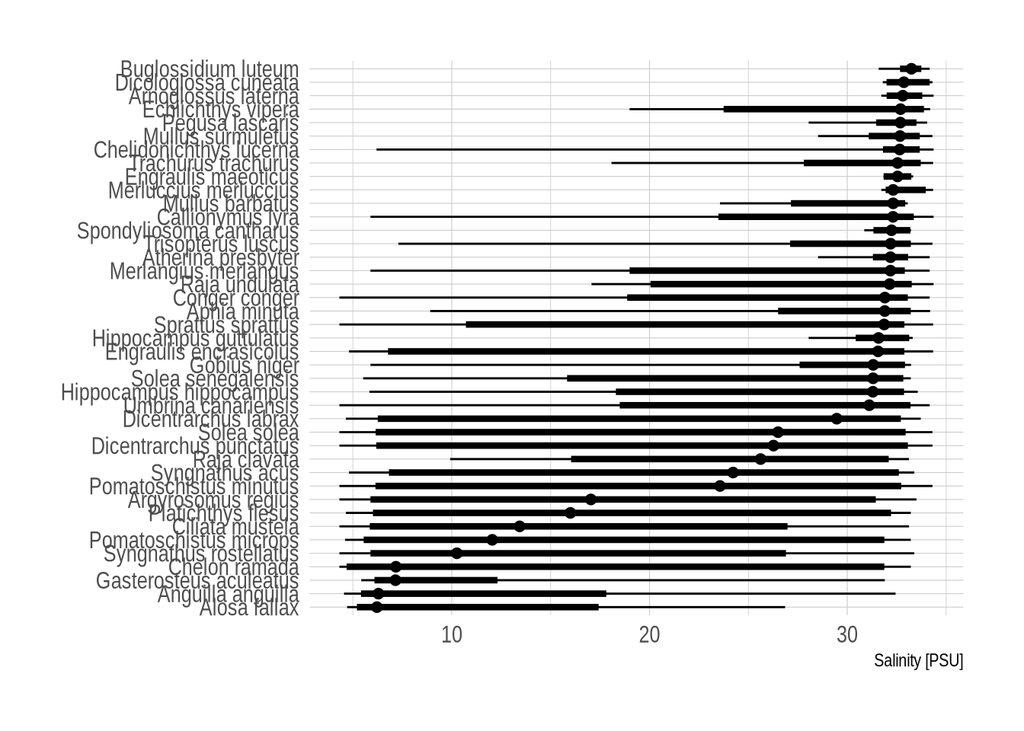

```r
niche <- niche |>
  arrange(salinity_med) |>
  mutate(
    species = factor(species, levels = species)
  )

ggplot(niche, aes(y = species)) +
  geom_segment(
    aes(x = salinity_q10, xend = salinity_q90, yend = species),
    linewidth = 1.5,
  ) +
  geom_segment(
    aes(x = salinity_min, xend = salinity_max, yend = species),
    linewidth = 0.5,
  ) +
  geom_point(aes(x = salinity_med), size = 2) +
  labs(x = "Salinity [PSU]", y = NULL)
```

We see that most species have wide salinity niche, meaning that they can endure high variability in salinity, these species notably comprise migratory species such as the Anguilla or the Alosa.

We find that most species have a wide salinity niche, which is not surprising for species found in estuaries. That said, a few species seem to be marine such as

- [Arnoglossus laterna](https://www.fishbase.se/summary/Arnoglossus-laterna.html)
- [Buglossidium luteum](https://fishbase.se/summary/Buglossidium-luteum)

which are both marine and dermersal species that live on sandy bottoms.

This analysis invites to couple our food web analysis with species traits to better understand what drives food web structure changes. In this regard, information about species migratory behaviour and whether they are benthic or pelagic. For example, change in food web structure could signal the apparition of a bentho-pelagic coupling.

## Community composition ordination

### Identify the salinity gradient as the main structuring axis

To ordinate communities along the salinity gradient, we first need to build the community matrix which indicate presence and absence of the different species for each site (or here fishing operation).

```r
community_matrix <- data |>
  filter(year > 2000) |>
  select(trait, species, year) |>
  tidyr::unnest(species) |>
  filter_out(species %in% rare_species) |>
  mutate(value = 1) |>
  tidyr::pivot_wider(
    names_from = species,
    values_fill = 0
  )
```

Next, we want to plot our ordinated communities along the salinity gradient, and visualise which species are driving the change in community composition. Typically, we would expect freshwater and marine species to drive the two ends of the gradient.

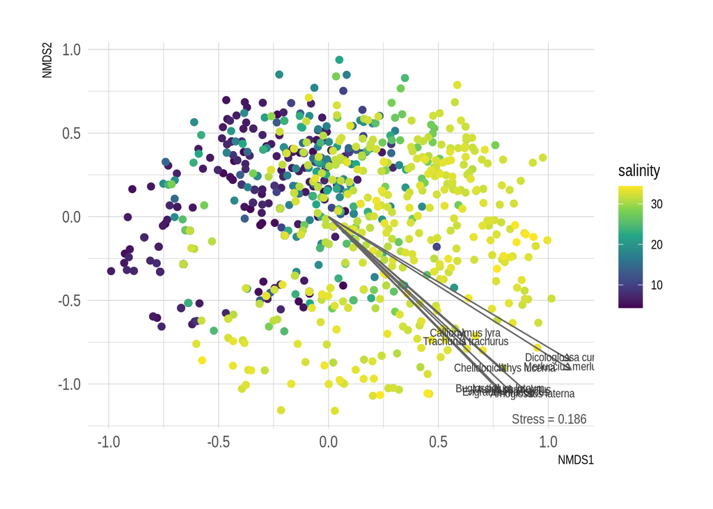

```r
scores_df <- as.data.frame(scores(nmds, display = "sites"))

scores_df$salinity <- community_matrix |>
  left_join(data, by = join_by(trait)) |>
  pull(salinity)

scores_df$salinity <- community_matrix |>
  left_join(data, by = join_by(trait)) |>
  pull(salinity)

sp_scores <- as.data.frame(scores(nmds, display = "species"))
sp_scores$species <- rownames(sp_scores)
sp_scores <- sp_scores |>
  mutate(r2 = NMDS1^2 + NMDS2^2) |>
  filter(r2 > quantile(r2, 0.8))

ggplot(scores_df, aes(x = NMDS1, y = NMDS2)) +
  geom_point(aes(colour = salinity), size = 2) +
  scale_colour_viridis_c() +
  geom_segment(
    data = sp_scores,
    aes(x = 0, y = 0, xend = NMDS1, yend = NMDS2),
    arrow = arrow(length = unit(0.2, "cm")),
    colour = "grey40", linewidth = 0.5
  ) +
  geom_text(
    data = sp_scores,
    aes(label = species), size = 3, colour = "grey20",
    nudge_y = 0.02
  ) +
  annotate("text",
    x = Inf, y = -Inf,
    label = paste("Stress =", round(nmds$stress, 3)),
    hjust = 1.1, vjust = -0.5, size = 3.5, colour = "grey30"
  )
```

We see that the main structuring axis of the community is salinity as could be expected. Second, we see that marine species (pointing to the right) seems to be the more structuring ones, which are the one we identified previously with our salinity niches. What is less clear is what is the other axis of variation. We could expect the habitat, and so, for example the presence of benthic species to be another structuring axis.

We can plot the our community on the map, coloring with NMDS first axis to see how are structure are communities in space.

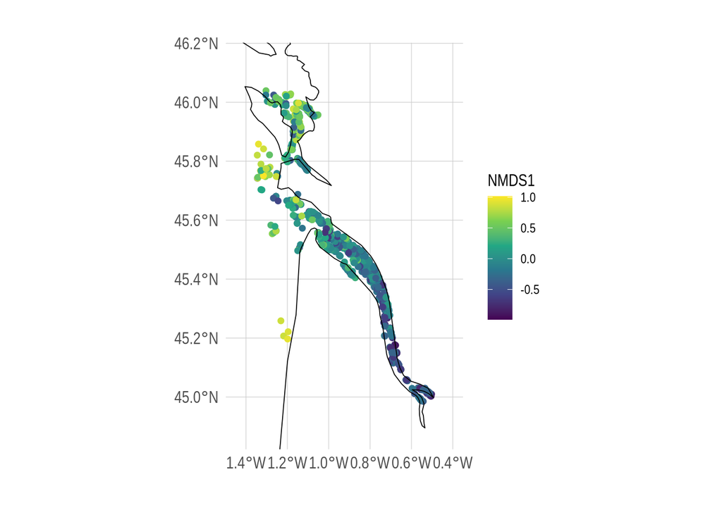

```r
scores_df$latitude <- community_matrix |>
  left_join(data, by = join_by(trait)) |>
  pull(latitude)
scores_df$longitude <- community_matrix |>
  left_join(data, by = join_by(trait)) |>
  pull(longitude)

ggplot(scores_df, aes(x = longitude, y = latitude, color = NMDS1)) +
  geom_point() +
  scale_colour_viridis_c() +
  geom_sf(data = coastline, inherit.aes = FALSE, linewidth = 0.3) +
  coord_sf(xlim = range(data$longitude) + e, ylim = range(data$latitude) + e) +
  labs(x = NULL, y = NULL)
```

They are struture along the estuary gradient. In particular, to visualise how salinity structure communities, we can plot the first axis of the NMDS against salinity.

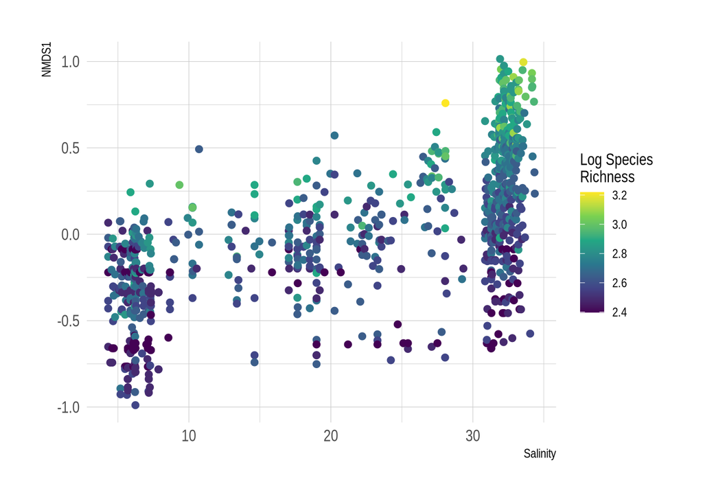

```r
scores_df$log_species_richness <- community_matrix |>
  left_join(data, by = join_by(trait)) |>
  pull(log_species_richness)

ggplot(scores_df, aes(x = salinity, y = NMDS1)) +
  geom_point(aes(colour = log_species_richness), size = 2) +
  scale_colour_viridis_c() +
  labs(x = "Salinity", colour = "Log Species\nRichness")
```

We see a positive association. As suggested by the relative high stress of the NMDS (~0.18), the community are difficult to ordinate. This may be due to to the noise related to the sampling process, sometimes we do not fish all species that are there. It may also be due to the fact that we aggregate points over the year and so we have differencies from one year to another.

### Identify structuring variables beyond salinity

We want to do a more general analysis to find which environmental variables structure our communities.

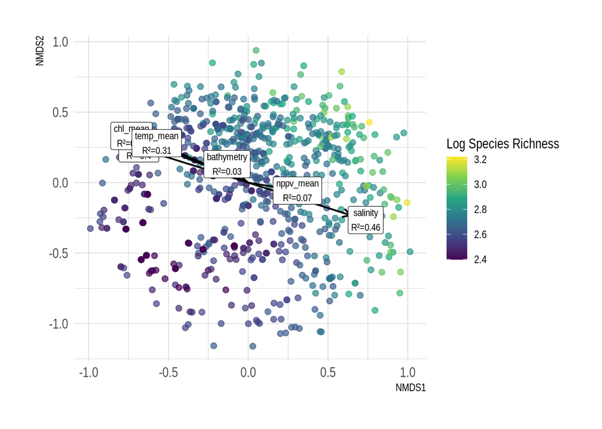

```r
env <- data |>
  select(
    trait, salinity, bathymetry, o2_mean, chl_mean, nppv_mean,
    temp_mean, year
  ) |>
  right_join(community_matrix |> select(trait, year), by = join_by(trait, year)) |>
  select(-c(trait, year))

fit <- envfit(nmds, env)

fit_df <- as.data.frame(scores(fit, display = "vectors"))
fit_df$variable <- rownames(fit_df)
fit_df$r2 <- fit$vectors$r
fit_df$p <- fit$vectors$pvals
fit_df <- fit_df |> filter(p <= 0.05)

ggplot(scores_df, aes(x = NMDS1, y = NMDS2)) +
  geom_point(aes(colour = log_species_richness), size = 2, alpha = 0.7) +
  scale_colour_viridis_c() +
  geom_segment(
    data = fit_df,
    aes(x = 0, y = 0, xend = NMDS1, yend = NMDS2),
    arrow = arrow(length = unit(0.25, "cm")),
    colour = "black", linewidth = 0.7
  ) +
  geom_label(
    data = fit_df,
    aes(
      x = NMDS1 * 1.15, y = NMDS2 * 1.15,
      label = paste0(variable, "\nR²=", round(r2, 2))
    ),
    size = 3, fill = "white", label.size = 0.2
  ) +
  labs(colour = "Log Species Richness")
```

We recover that most of the structure is driven by the salinity gradient and the correlated variable.